# Odds and Ends

- **16(!) challenges to make use of your new skills**
- Final Project Solution will be posted on Canvas (Next Week)

# This is (hopefully) only the beginning of your life in computing!!

# (1) add lines to you resume/CV

You can add the following lines to your resume:

- *Proficient in scientific programming in Python.*
- *Experienced with visualizing astronomical data*.

These will pique potential research advisors' interest!

# (2) apply for research positions

- You know enough Python to contribute meaningfully to space physics and astrophysical research!
- If you're interested:
  - Check out the projects at CU-[LASP](https://lasp.colorado.edu/home/)
  - Keep an eye on the [APS Research Employment Opportunities](https://www.colorado.edu/aps/undergraduate-studies/research-opportunities/aps-researchemployment-opportunities) page
  - Attend the APS [undergrad research symposium](http://www.colorado.edu/aps/undergraduate-studies/research-opportunities/undergrad-research-symposium) happens each year in December/January. Hype your coding skills!
  - Or just go talk to your favorite professor, grad student, or researcher!

# (3) learn more Python

The internet is full of awesome resources for Python. You have the scaffolding you need to continue to build your coding skills. For example:

- Jake VanderPlas has made notebooks associated with his new book *Python Data Science Handbook* [available](https://github.com/jakevdp/PythonDataScienceHandbook) via `github`. (Jake is an astronomer who likes to teach folks how to code; we've used some of his resources online.)
- The suggested textbooks on `Canvas` are really useful. They're all available for free through CU.
- nbviewer.jupyter.org hosts a bunch of notebooks on various topics.
- The `jupyter` project has a curated [gallery of interesting notebooks](https://github.com/jupyter/jupyter/wiki/A-gallery-of-interesting-Jupyter-Notebooks).
- Learn about [PySPEDAS](http://spedas.org/wiki/index.php?title=Getting_Started_with_pySPEDAS). This software allows you to access and view data from almost every NASA spacecraft.

# (4) google your Python questions

- What if you want to customize your legend to a plot in Python?
  - [Look for examples.](https://www.google.com/search?source=hp&ei=w23OX5yYEpSPtAai-4bIDQ&q=python+legend+matplotlib)
- `stackoverflow` is amazing = crowd-sourced coding advice.

### (watch out for `*args` and `**kwargs`)

Sometimes you'll see `*args` or `**kwargs` in Python documentation (for example, the official `matplotlib` documentation for [`legend`](http://matplotlib.org/api/pyplot_api.html#matplotlib.pyplot.legend)). This means the function is sending arguments and keyword arguments into other functions (making it not necessarily obvious what inputs the function expects). Keep reading (or check other resources)! Finding examples may be instructive.

# (5) profile the speed of your code

At some point, you're going to start caring about how fast your code runs. The `%time` magic command will tell you how long a code cell takes to run.

```python
import numpy as np
import matplotlib.pyplot as plt
%matplotlib inline
```

```python
plt.matplotlib.rcParams['figure.figsize'] = (7, 2)
plt.matplotlib.rcParams['figure.dpi'] = 100
```

```python
%time (np.random.random(1000000)).sort()
```

```
CPU times: user 114 ms, sys: 8.41 ms, total: 122 ms
Wall time: 133 ms
```

```python
%%timeit
(np.random.random(1000000)).sort()
```

```
104 ms ± 3.12 ms per loop (mean ± std. dev. of 7 runs, 10 loops each)
```

# (6) use arrays for speed

In general, using array math (e.g. `numpy` functions) is *much* faster than using loops. If speed matters, think about ways to "vectorize" your code.

```python
def loopadd(cube):
    '''Add 1 to each element in cube.'''
    for i in range(N):
        for j in range(N):
            for k in range(N):
                cube[i,j,k] += 1
    return cube

def numpyadd(cube):
    '''Add 1 to each element in cube.'''
    return cube + 1
```

We can use `%time` to compare the speeds of these two methods.

```python
N = 200
x = np.ones((N, N, N))
print(x.shape)
print(x.size)
```

```
(200, 200, 200)
8000000
```

```python
%time new = loopadd(x)
```

```
CPU times: user 5.55 s, sys: 45.5 ms, total: 5.59 s
Wall time: 5.75 s
```

```python
%time new = numpyadd(x)
```

```
CPU times: user 19.8 ms, sys: 24.6 ms, total: 44.4 ms
Wall time: 43.5 ms
```

# (7) visualize statistical datasets with `seaborn`

The `seaborn` package is useful for making quick beautiful plots, often with a statistical focus. You can use it to replace `matplotlib` if you want!

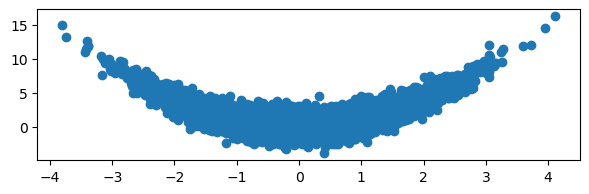

```python
x = np.random.normal(0, 1, 10000)
y = x**2 + np.random.normal(0, 1, 10000)
plt.scatter(x, y);
```

```python
import seaborn
seaborn.set(style="ticks")
```

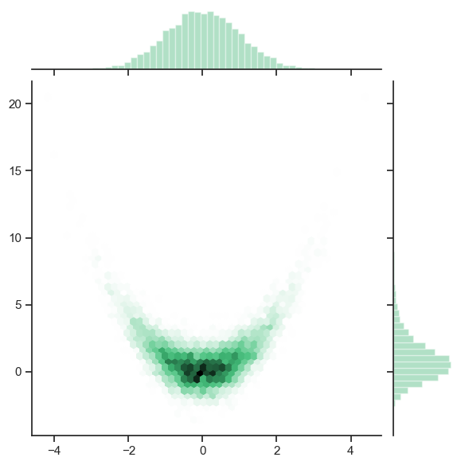

```python
xdata = np.random.normal(0, 1, 10000)
ydata = xdata**2 + np.random.normal(0, 1, 10000)
seaborn.jointplot(x=xdata, y=ydata, kind="hex", color="mediumseagreen");
```

# (8) play with `pandas`

[`pandas`](http://pandas.pydata.org/index.html) is a package that builds on top of `numpy`. We used it a little for reading tables. It's great for making *labeled* multidimensional arrays, dealing with messy or missing data, file input/output, and more. It's commonly used in data science communities. Go read about it!

# (9) use an Integrated Development Environment

There are more advanced tools to help you code in Python, beyond `jupyter notebook` or text editors. These can help correct code as you type it, enforce good style, test interactively, visualize variable creation, and more. Two popular ones are [PyCharm](https://www.jetbrains.com/pycharm/) and [Spyder](https://pythonhosted.org/spyder/) (already available on `scorpius`).

# (10) collaborate and share code

If you want to work collaboratively on a code project and/or share some of your code with the world, take the time to learn a code management system like [github](https://github.com), [bitbucket](https://bitbucket.org/product/), or [gitlab](https://about.gitlab.com). They all have great free and/or educational account options.

- They can help track and merge code changes, so you have a complete history of code development. (No more files that look like `code.py`, `code_v2.py`, `code-better-version.py`, `code_this-one-for-realsies.py`, `code_done-diddly-done.py`.)
- They have easy interfaces for tracking issues and discussions surrounding your code. (You: "It would be great if the code could to this."; Random internet folk: "OK, I'm on it!")
- They make it very easy to build off other existing codes and to let other folks build off your code. (If you have a good idea, you could contribute to `astropy`!)

# (11) install other folks' code

People have written very useful tools on the internet. For example, [what if I want to calculate model light curves for a planet passing in front of its star?](https://www.google.com/search?q=python+calculate+exoplanet+transit+light+curve)

General ways to install code for scientific programming:

- (sometimes), download and install like any other program
- `conda install name-of-program` (for Python, but also including any external dependencies)
- `pip install name-of-package` (for Python packages, most common)
- `git clone url-of-the-git-repository` (and then follow instructions)
- "compile from source" (sometimes easy, sometimes very complicated!)
- brew/homebrew (OS X)

If there's not good documentation on how to install some code, try to track down somebody who's installed and used it successfully.

# (12) code collaboratively in notebooks

Revisit your [Colaboratory](https://colab.research.google.com) notebook. There is much power in numbers. Trust your neighbors/classmates! and write codes as a team.

# (13) Discover `Jupyter` is more popular than you think!!

The [LIGO](https://www.ligo.org/) team has created some very cool `Jupyter` [notebook tutorials](https://losc.ligo.org/tutorials/) walking you through how the LIGO data is processed. You can go from raw data to Black Hole Chirps in a matter of seconds (*but you should probably read what the code is doing!*) Check it out...

The [Vera Rubin Telescope](https://www.lsst.org/) (aka LSST) will be releasing their data (and educational tools) via `Jupyter` [notebooks](https://doc.lsst.eu/tutorial/notebooks.html)!

# (14) publish with markdown, HTML, LaTeX

You've gotten very good at...

> I'm going to type this, and Python will interpret it in the following way...

You can create beautiful formatted documents by using various typsetting languages like Markdown (used by `jupyter` notebooks), HTML, and LaTeX. These interpret codes interspersed throughout plain text as how the document should be formatted.

The Tutorials have been written all semester long as Jupyter notebooks using Markdown!

[overleaf](https://www.overleaf.com) is a great way to get started if you want to make publication-quality PDFs.

# (15) learn *any* other programming language

You've learned one programming language. But, more importantly, you've learned how to think like a computer (aka how to specify instructions a computer should follow.)

*Learning another language will now be much easier.*

You will learn a translation into a new language, rather than learning to talk for the first time.

# (16) practice, practice, practice

As with any language or way of thinking, you need to practice it or you will forget.

- Strengthen those neural pathways. Build long-term memory.
- Use `python` daily, even if just as a **calculator**!
- Make nice documents that integrate words, equations, plots, and code.
- Incorporate your `python` skills into other things you do (classes, projects, creative endeavors, anything)!

# Any LAST Questions?

email: hadi.madanian@coloraro.edu

Go forth and code!

**And THANKS for a great semester!** I had so much fun teaching this course and getting back to teaching.